# A2 — Análisis descriptivo e inferencial

Víctor Suesta Arribas

## PR1

**Pregunta:** ¿La esperanza de vida es mayor en los países con alto nivel de ingresos que en el resto?

**1.2 Hipótesis.**  
H0: μ_high = μ_other  
H1: μ_high > μ_other (unilateral derecha). Muestra: año 2018.

**1.3 Test (justificación).**  
Comparo **dos medias** en muestras **independientes** con varianzas **desconocidas** (y posiblemente distintas) → **t de Welch** (dos muestras). Luego verifico con desarrollo propio usando `qt/pt`.

```r
# 1.4 Datos temporales de 2018 y agrupación High income vs Other
pr1 <- df |>
  dplyr::filter(year == 2018) |>
  dplyr::select(country, region, income, LE) |>
  tidyr::drop_na(LE, income) |>
  dplyr::mutate(
    grupo = factor(to_hi_other(income), levels = c("Other","High income"))
  )

# resúmenes cortos
summary(pr1$LE)
```

```
##    Min. 1st Qu.  Median    Mean 3rd Qu.    Max.
##   52.80   68.70   74.37   72.85   77.81   84.93
```

```r
table(pr1$grupo)
```

```
##
##       Other High income
##         120          53
```

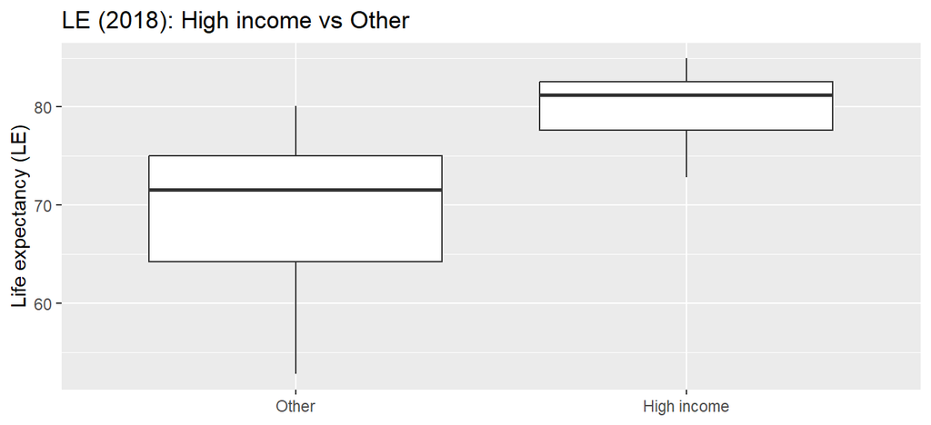

```r
# Gráfico descriptivo
ggplot(pr1, aes(x = grupo, y = LE)) +
  geom_boxplot() +
  labs(x = NULL, y = "Life expectancy (LE)",
       title = "LE (2018): High income vs Other")
```

```r
# 1.4 Aplicación con librería Con niveles c("Other","High income")
t_lib <- t.test(LE ~ grupo, data = pr1, alternative = "less")
t_lib
```

```
##
##  Welch Two Sample t-test
##
## data:  LE by grupo
## t = -13.668, df = 169.76, p-value < 2.2e-16
## alternative hypothesis: true difference in means between group Other and group High income is less than 0
## 95 percent confidence interval:
##       -Inf -9.018434
## sample estimates:
##       mean in group Other mean in group High income
##                  69.70942                  79.96936
```

```r
# 1.5 t de Welch (dos muestras independientes)
t_indep_manual <- function(x, g) {
  g <- factor(g, levels = c("Other","High income"))
  x1 <- x[g == "High income"]; x2 <- x[g == "Other"]
  n1 <- length(x1); n2 <- length(x2)
  m1 <- mean(x1);   m2 <- mean(x2)
  s1 <- var(x1);    s2 <- var(x2)
  t_obs <- (m1 - m2) / sqrt(s1/n1 + s2/n2)
  df_w  <- (s1/n1 + s2/n2)^2 / ((s1^2)/(n1^2*(n1-1)) + (s2^2)/(n2^2*(n2-1)))
  list(t_obs = t_obs, df = df_w, m1 = m1, m2 = m2, n1 = n1, n2 = n2)
}
```

```r
# 1.5 Verificación con mi función + p-valor con pt (unilateral derecha)
man <- t_indep_manual(pr1$LE, pr1$grupo)
p_manual <- 1 - pt(man$t_obs, df = man$df)

# 1.6 Resultados
res_tab <- data.frame(
  grupo = c("High income","Other"),
  n     = c(man$n1, man$n2),
  media = c(man$m1, man$m2)
)
print(res_tab, row.names = FALSE)
```

```
##        grupo   n    media
##  High income  53 79.96936
##        Other 120 69.70942
```

```r
diff_obs <- man$m1 - man$m2
cat(sprintf("Diferencia observada (High - Other) = %.2f\n", diff_obs))
```

```
## Diferencia observada (High - Other) = 10.26
```

```r
cat(sprintf("t = %.3f, gl = %.1f, p = %.4f\n", man$t_obs, man$df, p_manual))
```

```
## t = 13.668, gl = 169.8, p = 0.0000
```

```r
# 1.7 Interpretación
if (p_manual < 0.05) {
  cat("Conclusión: rechazo H0. Evidencia de LE mayor en High income (NC=95%).\n")
} else {
  cat("Conclusión: no rechazo H0 con α = 0.05.\n")
}
```

```
## Conclusión: rechazo H0. Evidencia de LE mayor en High income (NC=95%).
```

## PR2

**pregunta:** ¿La desigualdad se reduce en un período de 10 años?

**2.2 Hipótesis.**  
H0: μ_dif = 0  
H1: μ_dif < 0, con dif = GINI_2018 − GINI_2008 (reducción).

**2.3 Test (justificación).**  
Comparamos el **mismo país** en 2008 y 2018 → **t de Student apareado**. La alternativa es *less* porque esperamos **2018 < 2008**.

```r
# preparo pares por país y quito NA de GINI
pr2 <- df |>
  dplyr::filter(year %in% c(2008, 2018)) |>
  dplyr::select(country, region, year, GINI) |>
  tidyr::drop_na(GINI)

# mundo: formato ancho con países que tienen ambos años
wide_mundo <- pr2 |>
  dplyr::select(country, year, GINI) |>
  tidyr::pivot_wider(names_from = year, values_from = GINI) |>
  tidyr::drop_na(`2008`, `2018`) |>
  dplyr::rename(gini_2008 = `2008`, gini_2018 = `2018`)

# región: filtro antes de pivotar (así evito joins)
wide_reg <- pr2 |>
  dplyr::filter(region == "Europe and Northern America") |>
  dplyr::select(country, year, GINI) |>
  tidyr::pivot_wider(names_from = year, values_from = GINI) |>
  tidyr::drop_na(`2008`, `2018`) |>
  dplyr::rename(gini_2008 = `2008`, gini_2018 = `2018`)

# mini-chequeo
cat("n pares mundo =", nrow(wide_mundo), "\n")
```

```
## n pares mundo = 53
```

```r
cat("n pares región =", nrow(wide_reg), "\n")
```

```
## n pares región = 29
```

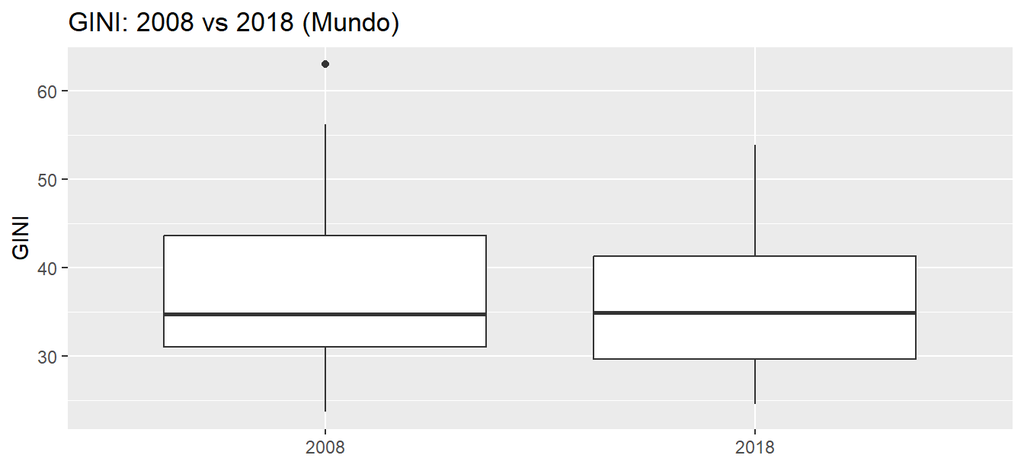

```r
# 2.1 boxplots mundo y región por año
ggplot(pr2, aes(x = factor(year), y = GINI)) +
  geom_boxplot() +
  labs(x = NULL, y = "GINI", title = "GINI: 2008 vs 2018 (Mundo)")
```

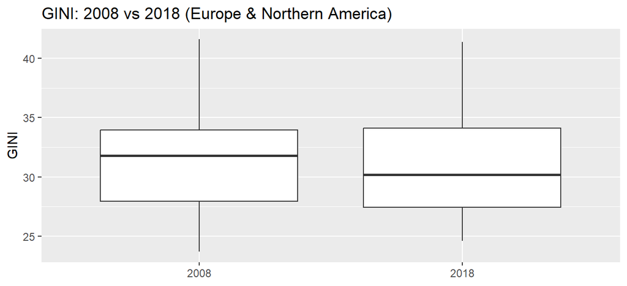

```r
ggplot(dplyr::filter(pr2, region == "Europe and Northern America"),
       aes(x = factor(year), y = GINI)) +
  geom_boxplot() +
  labs(x = NULL, y = "GINI", title = "GINI: 2008 vs 2018 (Europe & Northern America)")
```

```r
# 2.1 tablas top-5 y bottom-5 (mundo y región)
top_bot <- function(d, y, k = 5){
  dd <- d |>
    dplyr::filter(year == y) |>
    dplyr::arrange(dplyr::desc(GINI))
  list(
    top5    = head(dplyr::select(dd, country, GINI), k),
    bottom5 = head(dplyr::select(dplyr::arrange(dd, GINI), country, GINI), k)
  )
}

cat("MUNDO 2008 - TOP5\n")
```

```
## MUNDO 2008 - TOP5
```

```r
knitr::kable(top_bot(pr2, 2008)$top5, digits = 2)
```

| country | GINI |
| --- | --- |
| South Africa | 63.0 |
| Central African Republic | 56.2 |
| Honduras | 55.5 |
| Colombia | 55.3 |
| Brazil | 54.0 |

```r
cat("MUNDO 2008 - BOTTOM5\n")
```

```
## MUNDO 2008 - BOTTOM5
```

```r
knitr::kable(top_bot(pr2, 2008)$bottom5, digits = 2)
```

| country | GINI |
| --- | --- |
| Slovenia | 23.7 |
| Denmark | 25.2 |
| Slovak Republic | 26.0 |
| Czech Republic | 26.3 |
| Ukraine | 26.6 |

```r
cat("MUNDO 2018 - TOP5\n")
```

```
## MUNDO 2018 - TOP5
```

```r
knitr::kable(top_bot(pr2, 2018)$top5, digits = 2)
```

| country | GINI |
| --- | --- |
| Brazil | 53.9 |
| Angola | 51.3 |
| Colombia | 50.4 |
| Panama | 49.2 |
| Honduras | 48.9 |

```r
cat("MUNDO 2018 - BOTTOM5\n")
```

```
## MUNDO 2018 - BOTTOM5
```

```r
knitr::kable(top_bot(pr2, 2018)$bottom5, digits = 2)
```

| country | GINI |
| --- | --- |
| Slovenia | 24.6 |
| Czech Republic | 25.0 |
| Slovak Republic | 25.0 |
| Belarus | 25.2 |
| Moldova | 25.7 |

```r
pr2_reg <- dplyr::filter(pr2, region == "Europe and Northern America")
cat("\nREGIÓN 2008 - TOP5\n")
```

```
##
## REGIÓN 2008 - TOP5
```

```r
knitr::kable(top_bot(pr2_reg, 2008)$top5, digits = 2)
```

| country | GINI |
| --- | --- |
| Russian Federation | 41.6 |
| United States | 40.8 |
| Latvia | 37.2 |
| Portugal | 36.6 |
| Romania | 36.4 |

```r
cat("REGIÓN 2008 - BOTTOM5\n")
```

```
## REGIÓN 2008 - BOTTOM5
```

```r
knitr::kable(top_bot(pr2_reg, 2008)$bottom5, digits = 2)
```

| country | GINI |
| --- | --- |
| Slovenia | 23.7 |
| Denmark | 25.2 |
| Slovak Republic | 26.0 |
| Czech Republic | 26.3 |
| Ukraine | 26.6 |

```r
cat("REGIÓN 2018 - TOP5\n")
```

```
## REGIÓN 2018 - TOP5
```

```r
knitr::kable(top_bot(pr2_reg, 2018)$top5, digits = 2)
```

| country | GINI |
| --- | --- |
| United States | 41.4 |
| Bulgaria | 41.3 |
| Russian Federation | 37.5 |
| Romania | 35.8 |
| Lithuania | 35.7 |

```r
cat("REGIÓN 2018 - BOTTOM5\n")
```

```
## REGIÓN 2018 - BOTTOM5
```

```r
knitr::kable(top_bot(pr2_reg, 2018)$bottom5, digits = 2)
```

| country | GINI |
| --- | --- |
| Slovenia | 24.6 |
| Czech Republic | 25.0 |
| Slovak Republic | 25.0 |
| Belarus | 25.2 |
| Moldova | 25.7 |

```r
# 2.4 aplicación con librería: t apareado (2018 vs 2008), alternativa 'less'
t_mundo <- t.test(wide_mundo$gini_2018, wide_mundo$gini_2008,
                  paired = TRUE, alternative = "less")
t_reg   <- t.test(wide_reg$gini_2018,   wide_reg$gini_2008,
                  paired = TRUE, alternative = "less")

t_mundo
```

```
##
##  Paired t-test
##
## data:  wide_mundo$gini_2018 and wide_mundo$gini_2008
## t = -2.643, df = 52, p-value = 0.005417
## alternative hypothesis: true mean difference is less than 0
## 95 percent confidence interval:
##        -Inf -0.4721233
## sample estimates:
## mean difference
##       -1.288679
```

```r
t_reg
```

```
##
##  Paired t-test
##
## data:  wide_reg$gini_2018 and wide_reg$gini_2008
## t = -0.92225, df = 28, p-value = 0.1821
## alternative hypothesis: true mean difference is less than 0
## 95 percent confidence interval:
##       -Inf 0.4047998
## sample estimates:
## mean difference
##      -0.4793103
```

```r
# 2.5 t apareado
t_paired_manual <- function(y1, y2, side=c("two.sided","less","greater")){
  d <- y2 - y1
  n <- length(d)
  md <- mean(d); sd_d <- sd(d)
  t_obs <- md / (sd_d/sqrt(n))
  side <- match.arg(side)
  p <- switch(side,
              "two.sided" = 2*pt(-abs(t_obs), df=n-1),
              "less"      = pt(t_obs, df=n-1),
              "greater"   = 1-pt(t_obs, df=n-1))
  list(t_obs=t_obs, df=n-1, md=md, n=n, p=p)
}
```

```r
# 2.5 verificación: d = 2018 - 2008, buscamos d < 0 -> "less"
m_m <- t_paired_manual(wide_mundo$gini_2008, wide_mundo$gini_2018, side = "less")
m_r <- t_paired_manual(wide_reg$gini_2008,   wide_reg$gini_2018,   side = "less")

list(mundo = m_m, region = m_r)
```

```
## $mundo
## $mundo$t_obs
## [1] -2.642975
##
## $mundo$df
## [1] 52
##
## $mundo$md
## [1] -1.288679
##
## $mundo$n
## [1] 53
##
## $mundo$p
## [1] 0.005417203
##
##
## $region
## $region$t_obs
## [1] -0.922249
##
## $region$df
## [1] 28
##
## $region$md
## [1] -0.4793103
##
## $region$n
## [1] 29
##
## $region$p
## [1] 0.1821389
```

```r
# 2.6 resultados: medias 2008/2018 + dif (2018-2008) + t + gl + p
med_m_2008 <- mean(wide_mundo$gini_2008); med_m_2018 <- mean(wide_mundo$gini_2018)
med_r_2008 <- mean(wide_reg$gini_2008);   med_r_2018 <- mean(wide_reg$gini_2018)

cat(sprintf("Mundo:  media_2008 = %.2f, media_2018 = %.2f, dif = %.2f, t = %.3f, gl = %d, p = %.4f\n",
            med_m_2008, med_m_2018, m_m$md, m_m$t_obs, m_m$df, m_m$p))
```

```
## Mundo:  media_2008 = 37.06, media_2018 = 35.77, dif = -1.29, t = -2.643, gl = 52, p = 0.0054
```

```r
cat(sprintf("Región: media_2008 = %.2f, media_2018 = %.2f, dif = %.2f, t = %.3f, gl = %d, p = %.4f\n",
            med_r_2008, med_r_2018, m_r$md, m_r$t_obs, m_r$df, m_r$p))
```

```
## Región: media_2008 = 31.46, media_2018 = 30.98, dif = -0.48, t = -0.922, gl = 28, p = 0.1821
```

```r
# 2.7 interpretación
if (m_m$p < 0.05) {
  cat("Conclusión (mundo): rechazamos H0 → evidencia de reducción del GINI.\n")
} else {
  cat("Conclusión (mundo): no rechazamos H0 con α = 0.05.\n")
}
```

```
## Conclusión (mundo): rechazamos H0 → evidencia de reducción del GINI.
```

```r
if (m_r$p < 0.05) {
  cat("Conclusión (región): rechazamos H0 → evidencia de reducción del GINI.\n")
} else {
  cat("Conclusión (región): no rechazamos H0 con α = 0.05.\n")
}
```

```
## Conclusión (región): no rechazamos H0 con α = 0.05.
```

## PR3

**Pregunta:** ¿La proporción de países con mayor desigualdad es diferente entre los países con régimen democrático y aquellos con régimen autocrático?

**3.2 Hipótesis.**  
H0: p_dem = p_aut  
H1: p_dem ≠ p_aut  
(donde p_dem y p_aut son las proporciones de países con **GINI > 40** en 2018 en democracias y autocracias).

**3.3 Test (justificación).**  
Comparamos dos **proporciones** independientes → **contraste z de dos proporciones** (bilateral). Verificamos con `prop.test` y con desarrollo propio usando `pnorm`.

```r
# 3.1 Preparación (muestra 2018, solo columnas necesarias, sin NA)
pr3 <- df |>
  dplyr::filter(year == 2018) |>
  dplyr::select(country, regime, GINI) |>
  tidyr::drop_na(regime, GINI) |>
  dplyr::mutate(
    high_inequality = as.integer(GINI > 40),
    regime2 = ifelse(grepl("Democ", regime, ignore.case = TRUE), "Democracy", "Autocracy"),
    regime2 = factor(regime2, levels = c("Democracy","Autocracy"))
  )

# Tabla de proporciones por régimen
tab <- pr3 |>
  dplyr::group_by(regime2) |>
  dplyr::summarise(
    n = dplyr::n(),
    x = sum(high_inequality),
    p_hat = x / n,
    .groups = "drop"
  )

# tabla de proporción observada
knitr::kable(tab, digits = 3)
```

| regime2 | n | x | p_hat |
| --- | --- | --- | --- |
| Democracy | 47 | 13 | 0.277 |
| Autocracy | 17 | 5 | 0.294 |

```r
# Tabla 2x2 de conteos
table(pr3$regime2, pr3$high_inequality)
```

```
##
##              0  1
##   Democracy 34 13
##   Autocracy 12  5
```

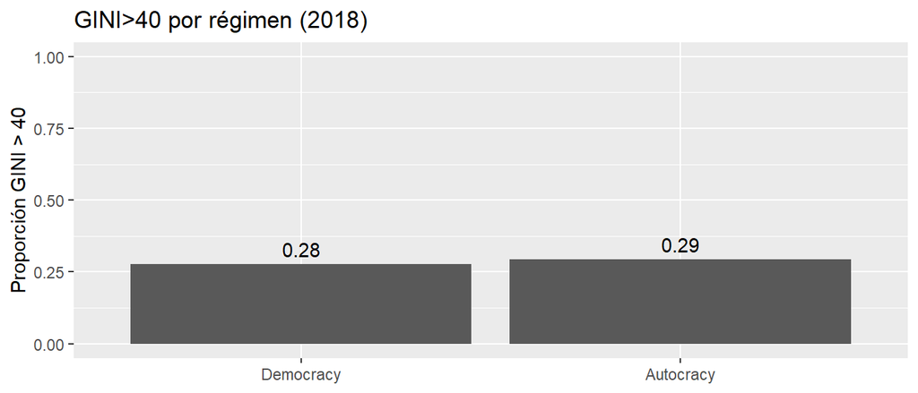

```r
# 3.1 Gráfico de proporciones observadas
ggplot(tab, aes(x = regime2, y = p_hat)) +
  geom_col() +
  geom_text(aes(label = sprintf("%.2f", p_hat)), vjust = -0.5) +
  ylim(0, 1) +
  labs(x = NULL, y = "Proporción GINI > 40",
       title = "GINI>40 por régimen (2018)")
```

```r
# 3.4 Aplicación con librería
x <- tab$x
n <- tab$n
prop_lib <- prop.test(x = x, n = n, alternative = "two.sided", correct = FALSE)
prop_lib
```

```
##
##  2-sample test for equality of proportions without continuity correction
##
## data:  x out of n
## X-squared = 0.018961, df = 1, p-value = 0.8905
## alternative hypothesis: two.sided
## 95 percent confidence interval:
##  -0.2690529  0.2340091
## sample estimates:
##    prop 1    prop 2
## 0.2765957 0.2941176
```

```r
# 3.5 z con p combinada
prop2_manual <- function(x1, n1, x2, n2, side = c("two.sided","less","greater")){
  p_hat <- (x1 + x2) / (n1 + n2)
  z_obs <- (x1/n1 - x2/n2) / sqrt(p_hat * (1 - p_hat) * (1/n1 + 1/n2))
  side <- match.arg(side)
  p <- switch(side,
              "two.sided" = 2*pnorm(-abs(z_obs)),
              "less"      = pnorm(z_obs),
              "greater"   = 1 - pnorm(z_obs))
  list(z_obs = z_obs,
       p = p,
       p1 = x1/n1,
       p2 = x2/n2,
       n1 = n1, n2 = n2)
}
```

```r
# 3.5 Verificación (bilateral)
pm <- prop2_manual(
  x1 = tab$x[tab$regime2 == "Democracy"], n1 = tab$n[tab$regime2 == "Democracy"],
  x2 = tab$x[tab$regime2 == "Autocracy"],  n2 = tab$n[tab$regime2 == "Autocracy"],
  side = "two.sided"
)

# 3.6 Resultados (valores calculados, valor observado, estadístico, p)
diff_obs <- pm$p1 - pm$p2
res_tab <- data.frame(
  grupo = c("Democracy","Autocracy"),
  n = c(pm$n1, pm$n2),
  x = c(round(pm$p1*pm$n1), round(pm$p2*pm$n2)),
  prop = c(pm$p1, pm$p2)
)
knitr::kable(res_tab, digits = 3)
```

| grupo | n | x | prop |
| --- | --- | --- | --- |
| Democracy | 47 | 13 | 0.277 |
| Autocracy | 17 | 5 | 0.294 |

```r
cat(sprintf("Valor observado (p_dem - p_aut) = %.3f\n", diff_obs))
```

```
## Valor observado (p_dem - p_aut) = -0.018
```

```r
cat(sprintf("z = %.3f, p = %.4f (bilateral)\n", pm$z_obs, pm$p))
```

```
## z = -0.138, p = 0.8905 (bilateral)
```

```r
# 3.7 Interpretación
if (pm$p < 0.05) {
  cat("Conclusión: rechazo H0 → la proporción de GINI>40 difiere entre regímenes.\n")
} else {
  cat("Conclusión: no rechazo H0 con α = 0.05.\n")
}
```

```
## Conclusión: no rechazo H0 con α = 0.05.
```

## PR4

**Pregunta:** ¿La proporción de países que cumplen con el objetivo de no agotamiento neto de bosques es mayor que 50 %?

**4.2 Hipótesis.**  
H0: p = 0.5  
H1: p > 0.5, donde p es la proporción de países con **FOR ≤ 0** en 2018.

**4.3 Test (justificación).**  
Se contrasta **una proporción** frente a un valor **p0 = 0.5** → **test z de una proporción** (unilateral derecha). Verifico con `prop.test` y con desarrollo propio usando `pnorm`.

```r
# 4.1 Datos 2018 y variable binaria de "no agotamiento" (éxito = 1 si FOR ≤ 0)
pr4 <- df |>
  dplyr::filter(year == 2018) |>
  dplyr::select(country, FOR) |>
  tidyr::drop_na(FOR) |>
  dplyr::mutate(no_agotamiento = as.integer(FOR <= 0))

# conteos básicos
n  <- nrow(pr4)
x  <- sum(pr4$no_agotamiento)
ph <- x / n

# chequeo rapido
data.frame(n_total = n, exitos = x, ph_observada = ph)
```

```
##   n_total exitos ph_observada
## 1     162     95    0.5864198
```

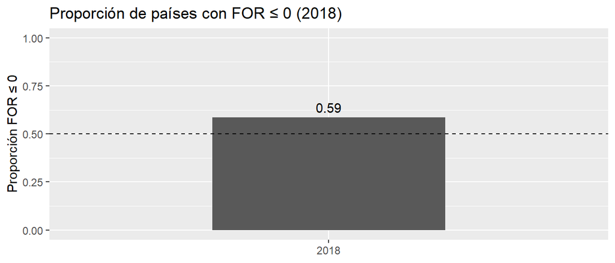

```r
# 4.1 Gráfico: barra con la proporción observada y línea en 0.5
ggplot(data.frame(grupo = "2018", ph = ph), aes(x = grupo, y = ph)) +
  geom_col(width = 0.5) +
  geom_hline(yintercept = 0.5, linetype = 2) +
  geom_text(aes(label = sprintf("%.2f", ph)), vjust = -0.5) +
  ylim(0, 1) +
  labs(x = NULL, y = "Proporción FOR ≤ 0",
       title = "Proporción de países con FOR ≤ 0 (2018)")
```

```r
# 4.4 1 proporción vs p0=0.5 (unilateral derecha)
prop1_lib <- prop.test(x = x, n = n, p = 0.5,
                       alternative = "greater", correct = FALSE)
prop1_lib
```

```
##
##  1-sample proportions test without continuity correction
##
## data:  x out of n, null probability 0.5
## X-squared = 4.8395, df = 1, p-value = 0.01391
## alternative hypothesis: true p is greater than 0.5
## 95 percent confidence interval:
##  0.5218656 1.0000000
## sample estimates:
##         p
## 0.5864198
```

```r
# 4.5 z con p0
prop1_manual <- function(x, n, p0 = 0.5, side = c("two.sided","less","greater")){
  ph <- x / n
  z_obs <- (ph - p0) / sqrt(p0 * (1 - p0) / n)
  side <- match.arg(side)
  p <- switch(side,
              "two.sided" = 2*pnorm(-abs(z_obs)),
              "less"      = pnorm(z_obs),
              "greater"   = 1 - pnorm(z_obs))
  list(z_obs = z_obs, p = p, ph = ph, n = n, p0 = p0)
}
```

```r
# 4.5 Verificación (unilateral)
pm1 <- prop1_manual(x = x, n = n, p0 = 0.5, side = "greater")
pm1
```

```
## $z_obs
## [1] 2.199888
##
## $p
## [1] 0.01390743
##
## $ph
## [1] 0.5864198
##
## $n
## [1] 162
##
## $p0
## [1] 0.5
```

```r
# 4.6 Resultados: valor mostral, estadístico observado y p-valor
cat(sprintf("Proporción muestral (ph) = %.3f (x=%d, n=%d)\n", pm1$ph, x, n))
```

```
## Proporción muestral (ph) = 0.586 (x=95, n=162)
```

```r
cat(sprintf("Estadístico observado z = %.3f\n", pm1$z_obs))
```

```
## Estadístico observado z = 2.200
```

```r
cat(sprintf("p-valor (unilateral > 0.5) = %.4f\n", pm1$p))
```

```
## p-valor (unilateral > 0.5) = 0.0139
```

```r
# 4.7 Interpretación (α = 0.05)
if (pm1$p < 0.05) {
  cat("Conclusión: rechazo H0 → evidencia de que la proporción de FOR ≤ 0 es > 50%.\n")
} else {
  cat("Conclusión: no rechazo H0 con α = 0.05.\n")
}
```

```
## Conclusión: rechazo H0 → evidencia de que la proporción de FOR ≤ 0 es > 50%.
```

## 5. Tabla final de conclusiones (PR1–PR4)

**Resumen:** test aplicado, estadístico, gl (si aplica), *p* y conclusión (NC 95 %).

```r
resumen <- tibble::tibble(
  PR        = c("PR1", "PR2-mundo", "PR2-región", "PR3", "PR4"),
  Pregunta  = c(
    "¿LE mayor en High income?",
    "¿GINI 2018 < 2008 (mundo)?",
    "¿GINI 2018 < 2008 (Europe & N. America)?",
    "¿p(GINI>40) difiere entre regímenes?",
    "¿p(FOR ≤ 0) > 0.5?"
  ),
  Test      = c(
    "t de Welch (2 ind., >)",
    "t apareado (<)",
    "t apareado (<)",
    "2 proporciones (bilateral)",
    "1 proporción (> 0.5)"
  ),
  Estadistico = c(
    sprintf("t=%.3f (gl≈%.1f)", man$t_obs, man$df),
    sprintf("t=%.3f (gl=%d)",   m_m$t_obs, m_m$df),
    sprintf("t=%.3f (gl=%d)",   m_r$t_obs, m_r$df),
    sprintf("z=%.3f",           pm$z_obs),
    sprintf("z=%.3f",           pm1$z_obs)
  ),
  p_value = c(
    sprintf("%.4f", p_manual),
    sprintf("%.4f", m_m$p),
    sprintf("%.4f", m_r$p),
    sprintf("%.4f", pm$p),
    sprintf("%.4f", pm1$p)
  ),
  Conclusión = c(
    ifelse(p_manual < 0.05, "Rechazo H0: LE mayor en High income", "No rechazo H0"),
    ifelse(m_m$p     < 0.05, "Rechazo H0: GINI ↓ (mundo)",         "No rechazo H0"),
    ifelse(m_r$p     < 0.05, "Rechazo H0: GINI ↓ (región)",        "No rechazo H0"),
    ifelse(pm$p      < 0.05, "Rechazo H0: proporciones distintas", "No rechazo H0"),
    ifelse(pm1$p     < 0.05, "Rechazo H0: p(FOR≤0) > 0.5",         "No rechazo H0")
  )
)

resumen
```

```
## # A tibble: 5 × 6
##   PR         Pregunta                       Test  Estadistico p_value Conclusión
##   <chr>      <chr>                          <chr> <chr>       <chr>   <chr>
## 1 PR1        ¿LE mayor en High income?      t de… t=13.668 (… 0.0000  Rechazo H…
## 2 PR2-mundo  ¿GINI 2018 < 2008 (mundo)?     t ap… t=-2.643 (… 0.0054  Rechazo H…
## 3 PR2-región ¿GINI 2018 < 2008 (Europe & N… t ap… t=-0.922 (… 0.1821  No rechaz…
## 4 PR3        ¿p(GINI>40) difiere entre reg… 2 pr… z=-0.138    0.8905  No rechaz…
## 5 PR4        ¿p(FOR ≤ 0) > 0.5?             1 pr… z=2.200     0.0139  Rechazo H…
```

```r
# tabla para el informe
knitr::kable(
  resumen,
  digits = 3,
  caption = "Resumen PR1–PR4 (NC 95 %)"
)
```

Resumen PR1–PR4 (NC 95 %)

| PR | Pregunta | Test | Estadistico | p_value | Conclusión |
| --- | --- | --- | --- | --- | --- |
| PR1 | ¿LE mayor en High income? | t de Welch (2 ind., >) | t=13.668 (gl≈169.8) | 0.0000 | Rechazo H0: LE mayor en High income |
| PR2-mundo | ¿GINI 2018 < 2008 (mundo)? | t apareado (<) | t=-2.643 (gl=52) | 0.0054 | Rechazo H0: GINI ↓ (mundo) |
| PR2-región | ¿GINI 2018 < 2008 (Europe & N. America)? | t apareado (<) | t=-0.922 (gl=28) | 0.1821 | No rechazo H0 |
| PR3 | ¿p(GINI>40) difiere entre regímenes? | 2 proporciones (bilateral) | z=-0.138 | 0.8905 | No rechazo H0 |
| PR4 | ¿p(FOR ≤ 0) > 0.5? | 1 proporción (> 0.5) | z=2.200 | 0.0139 | Rechazo H0: p(FOR≤0) > 0.5 |